# Bike Share Case Study - 2 - Data Preparation

This data preparation notebook will record the loading, cleaning, manipulation, and exploration of the data set.

# Loading the data

First we’ll load some R libraries.

```r
library(tidyverse)
```

```r
library(lubridate)
```

```r
library(gridExtra)
```

The data set consists of 12 monthly CSV files of bike share data for the year 2021. Visual inspection of the files showed there were 13 columns per file, and the column names were consistent across all files. The number of records in the 12 files totaled to 5,595,063.

We’ll read the 12 files into a tibble called bike_share. The columns with categorical data (rideable_type and member_casual) should be factors.

```r
bike_share_files <- list.files(
                      path = "2 Extracted Data",
                      pattern = '*.csv',
                      full.names = TRUE
                    )

column_types <- cols(rideable_type = col_factor(), member_casual = col_factor())

bike_share <- map_dfr(bike_share_files, read_csv, col_types = column_types)
```

Let’s take a look at the data using glimpse().

```r
glimpse(bike_share)
```

```
Rows: 5,595,063
Columns: 13
$ ride_id            <chr> "E19E6F1B8D4C42ED", "DC88F20C2C55F27F", "EC45C94683FE3F~
$ rideable_type      <fct> electric_bike, electric_bike, electric_bike, electric_b~
$ started_at         <dttm> 2021-01-23 16:14:19, 2021-01-27 18:43:08, 2021-01-21 2~
$ ended_at           <dttm> 2021-01-23 16:24:44, 2021-01-27 18:47:12, 2021-01-21 2~
$ start_station_name <chr> "California Ave & Cortez St", "California Ave & Cortez ~
$ start_station_id   <chr> "17660", "17660", "17660", "17660", "17660", "17660", "~
$ end_station_name   <chr> NA, NA, NA, NA, NA, NA, NA, NA, NA, "Wood St & Augusta ~
$ end_station_id     <chr> NA, NA, NA, NA, NA, NA, NA, NA, NA, "657", "13258", "65~
$ start_lat          <dbl> 41.90034, 41.90033, 41.90031, 41.90040, 41.90033, 41.90~
$ start_lng          <dbl> -87.69674, -87.69671, -87.69664, -87.69666, -87.69670, ~
$ end_lat            <dbl> 41.89000, 41.90000, 41.90000, 41.92000, 41.90000, 41.94~
$ end_lng            <dbl> -87.72000, -87.69000, -87.70000, -87.69000, -87.70000, ~
$ member_casual      <fct> member, member, member, member, casual, casual, member,~
```

There are 5,595,063 rows and 13 columns as expected. The data includes:

- Ride ID
- Type of bike (rideable_type)
- Start and end datetimes for the ride
- Names and IDs of the stations at which the ride started and ended
- Latitude and longitude where the ride started and ended
- Whether the customer was a member or a casual rider

# Creating additional columns

Let’s use the started_at datetime to create columns for the quarter, month, week, day of the week, day of the month, and hour the ride started. Let’s also create a column for the duration of the ride.

```r
bike_share <- bike_share %>%
  mutate(
    start_quarter = quarter(started_at),
    start_month   = factor(month(started_at, label = TRUE)),
    start_week    = week(started_at),
    start_wday    = factor(wday(started_at, label = TRUE)),
    start_mday    = mday(started_at),
    start_hour    = hour(started_at),
    ride_duration = as.duration(interval(start = started_at, end = ended_at))
  )
```

Let’s rearrange the order of the days of the week to run from Monday to Sunday.

```r
bike_share$start_wday <- fct_relevel(bike_share$start_wday, "Sun", after = 6)
```

Let’s create a ride “displacement” column using the latitude and longitude data. This can be used to compare relative distances between the starting and ending locations of rides. It does not indicate distance using any standard unit of measure.

```r
bike_share <- bike_share %>%
  mutate(
    ride_displacement = sqrt((end_lat - start_lat)^2 + (end_lng - start_lng)^2)
  )
```

Let’s take a look at the new columns.

```r
glimpse(bike_share)
```

```
Rows: 5,595,063
Columns: 21
$ ride_id            <chr> "E19E6F1B8D4C42ED", "DC88F20C2C55F27F", "EC45C94683FE3F~
$ rideable_type      <fct> electric_bike, electric_bike, electric_bike, electric_b~
$ started_at         <dttm> 2021-01-23 16:14:19, 2021-01-27 18:43:08, 2021-01-21 2~
$ ended_at           <dttm> 2021-01-23 16:24:44, 2021-01-27 18:47:12, 2021-01-21 2~
$ start_station_name <chr> "California Ave & Cortez St", "California Ave & Cortez ~
$ start_station_id   <chr> "17660", "17660", "17660", "17660", "17660", "17660", "~
$ end_station_name   <chr> NA, NA, NA, NA, NA, NA, NA, NA, NA, "Wood St & Augusta ~
$ end_station_id     <chr> NA, NA, NA, NA, NA, NA, NA, NA, NA, "657", "13258", "65~
$ start_lat          <dbl> 41.90034, 41.90033, 41.90031, 41.90040, 41.90033, 41.90~
$ start_lng          <dbl> -87.69674, -87.69671, -87.69664, -87.69666, -87.69670, ~
$ end_lat            <dbl> 41.89000, 41.90000, 41.90000, 41.92000, 41.90000, 41.94~
$ end_lng            <dbl> -87.72000, -87.69000, -87.70000, -87.69000, -87.70000, ~
$ member_casual      <fct> member, member, member, member, casual, casual, member,~
$ start_quarter      <int> 1, 1, 1, 1, 1, 1, 1, 1, 1, 1, 1, 1, 1, 1, 1, 1, 1, 1, 1~
$ start_month        <ord> Jan, Jan, Jan, Jan, Jan, Jan, Jan, Jan, Jan, Jan, Jan, ~
$ start_week         <dbl> 4, 4, 3, 1, 4, 2, 1, 2, 2, 4, 4, 2, 2, 4, 4, 1, 5, 4, 3~
$ start_wday         <ord> Sat, Wed, Thu, Thu, Sat, Sat, Mon, Thu, Sat, Sun, Sat, ~
$ start_mday         <int> 23, 27, 21, 7, 23, 9, 4, 14, 9, 24, 23, 9, 9, 24, 22, 5~
$ start_hour         <int> 16, 18, 22, 13, 2, 14, 5, 15, 9, 19, 12, 15, 15, 15, 15~
$ ride_duration      <Duration> 625s (~10.42 minutes), 244s (~4.07 minutes), 80s (~
$ ride_displacement  <dbl> 0.025452258, 0.006715253, 0.003371861, 0.020702578, 0.0~
```

# Exlporing and cleaning the data

Our goal is to check the data for completeness and consistency, and to identify potential data issues. We’ll clean up issues when it’s reasonable to do so, and along the way we’ll learn how customers use the bike share service. Hopefully we’ll glean an understanding of the data that we’ll put to use when we later analyze the differences in bike usage between members and casual riders.

### Checking for missing data and duplicate data

Let’s get percentages of missing values in the data set.

```r
bike_share %>%
  map(is.na) %>%
  map_dbl(mean) %>%
  keep(. > 0 ) * 100
```

```
start_station_name   start_station_id   end_station_name     end_station_id
        12.3467600         12.3467064         13.2111113         13.2111113
           end_lat            end_lng  ride_displacement
         0.0852716          0.0852716          0.0852716
```

There are significant numbers of rides with missing station names and IDs. A few station latitudes and longitudes are also missing, but only for end stations. This affects the ride displacement values, since latitudes and longitudes are used to calculate ride displacement.

Let’s check for duplicate ride IDs.

```r
n_distinct(bike_share$ride_id)
```

```
[1] 5595063
```

There are no duplicate ride IDs.

We can also look for duplicates by checking for rides that start and end at the same times and stations, and have the same value for rideable_type. We’ll put these rides in a tibble called duplicate_rides.

```r
duplicate_rides <- bike_share %>%
  group_by(
    started_at,
    ended_at,
    start_station_name,
    end_station_name,
    rideable_type
  ) %>%
  summarize(count = n(), .groups = "keep") %>%
  filter(count > 1) %>%
  arrange(desc(count), started_at, ended_at)
```

Let’s take a look at these rides.

```r
print(duplicate_rides, n = Inf)
```

| started_at | ended_at | start_station_name | end_station_name | rideable_type | count |
| --- | --- | --- | --- | --- | --- |
| 2021-08-28 21:16:47 | 2021-08-28 21:30:55 | Bissell St & Armitage Ave | Wells St & Evergreen Ave | classic_bike | 3 |
| 2021-01-20 12:03:27 | 2021-01-20 12:08:31 | Wells St & Huron St | Kingsbury St & Kinzie St | classic_bike | 2 |
| 2021-01-29 15:26:52 | 2021-01-29 15:32:16 | Wabash Ave & Wacker Pl | LaSalle St & Jackson Blvd | electric_bike | 2 |
| 2021-01-29 19:39:15 | 2021-01-29 19:56:29 | Ellis Ave & 60th St | Kimbark Ave & 53rd St | classic_bike | 2 |
| 2021-03-05 14:02:36 | 2021-03-05 14:31:30 | Field Museum | Green St & Randolph St | classic_bike | 2 |
| 2021-03-05 17:29:01 | 2021-03-05 18:03:25 | Adler Planetarium | Calumet Ave & 21st St | classic_bike | 2 |
| 2021-03-07 07:53:48 | 2021-03-07 08:18:35 | Adler Planetarium | Adler Planetarium | classic_bike | 2 |
| 2021-03-07 14:45:41 | 2021-03-07 14:57:13 | Michigan Ave & Pearson St | Rush St & Superior St | docked_bike | 2 |
| 2021-03-09 07:55:12 | 2021-03-09 08:19:35 | Larrabee St & Webster Ave | California Ave & Montrose Ave | classic_bike | 2 |
| 2021-03-12 16:05:32 | 2021-03-12 16:16:21 | Wells St & Hubbard St | Wells St & Evergreen Ave | electric_bike | 2 |

[output cut: 627 more lines]

There are 636 pairs of rides with the same times, stations, and rideable_type. And there’s one triplet of such rides. There doesn’t appear to be any specific station or type of bike associated with these duplicate rides.

Let’s look at the distribution of these rides by week (week 1 being the first week of 2021).

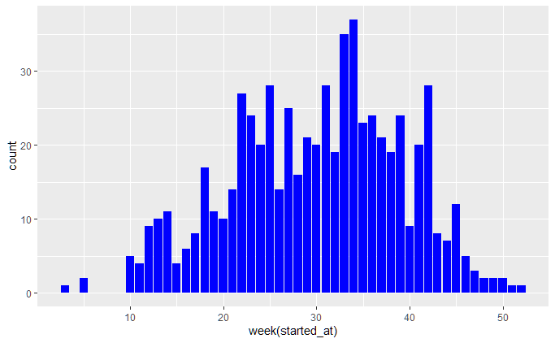

```r
duplicate_rides %>%
  ggplot(mapping = aes(x = week(started_at))) +
  geom_bar(fill = "blue")
```

Considering that we expect more rides to take place during warmer weather, the duplicate rides aren’t concentrated in any particular time period.

Let’s see whether these rides are associated with a particular part of the week or hour of the day.

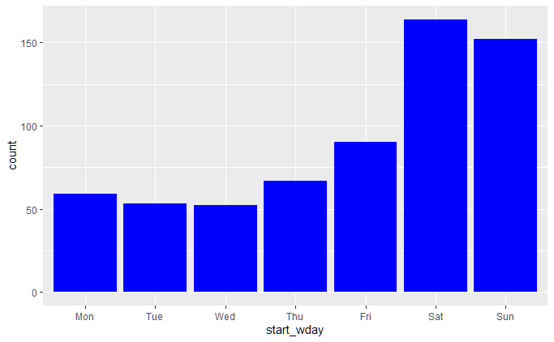

```r
duplicate_rides %>%
  ungroup %>%
  mutate(start_wday = factor(
                        wday(duplicate_rides$started_at, label = TRUE),
                        levels = levels(bike_share$start_wday)
                      )
  ) %>%
  ggplot(mapping = aes(x = start_wday)) +
  geom_bar(fill = "blue")
```

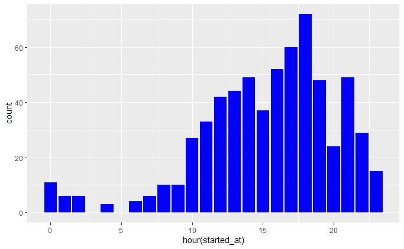

```r
duplicate_rides %>%
  ggplot(mapping = aes(x = hour(started_at))) +
  geom_bar(fill = "blue")
```

These duplicate rides are more common on weekends and afternoons, but that may be true of rides generally. There doesn’t appear to be any particular time of the day, week, or year associated with duplicate rides.

It’s possible that two or three bikes can be checked out and checked in together. Since the number of these rides is low, we’ll leave them in the data set and make a note in the data summary.

### Exploring - member_casual

Let’s look at the values in the member_casual column.

```r
levels(bike_share$member_casual)
```

```
[1] "member" "casual"
```

There are only two values, member and casual, which are the groups we want to compare in our analysis. Let’s take a look at the number of rides for each.

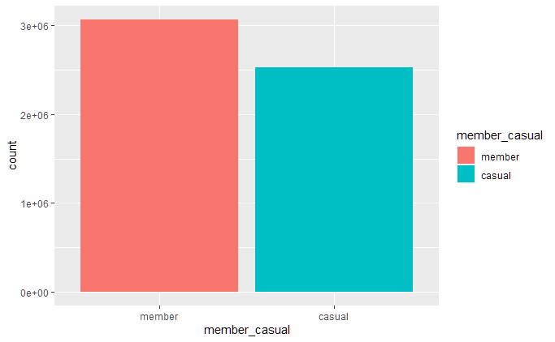

```r
bike_share %>%
  ggplot(mapping = aes(x = member_casual)) +
  geom_bar(mapping = aes(fill = member_casual))
```

There are about 3.0 million rides by members, and about 2.5 million rides by casual riders. We’ll look more closely at the differences between members and casual riders after we finish exploring and cleaning the data set.

### Exploring - rideable_type

Let’s look at the values for rideable_type:

```r
levels(bike_share$rideable_type)
```

```
[1] "electric_bike" "classic_bike"  "docked_bike"
```

There are three values: electric bike, classic bike, and docked bike. Let’s take a look at the number of rides for each type of bike.

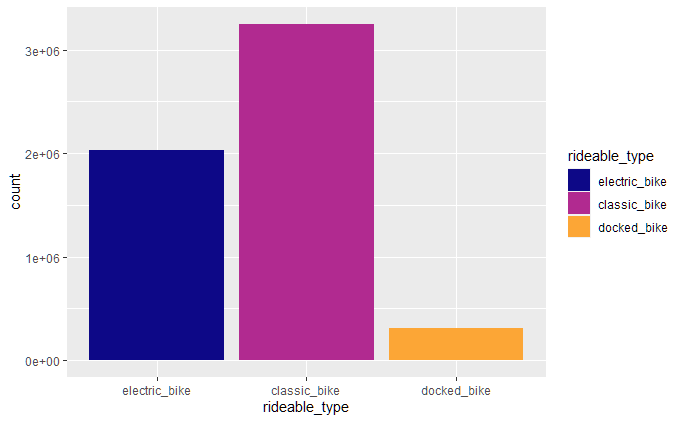

```r
bike_share %>%
  ggplot() +
  geom_bar(mapping = aes(x = rideable_type, fill = rideable_type)) +
  scale_fill_viridis_d(option = "plasma", end = 0.8, drop = FALSE)
```

The docked bikes are used a lot less often than the other two types. It’s possible they were introduced recently, or maybe removed from service early in the year. Let’s check that by looking at monthly counts.

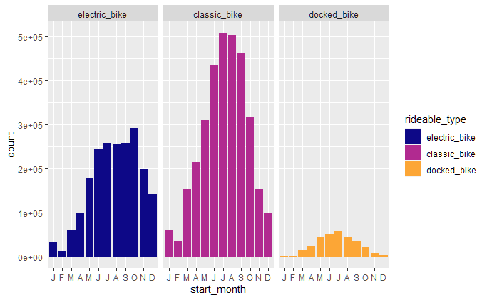

```r
bike_share %>%
  ggplot() +
  geom_bar(mapping = aes(x = start_month, fill = rideable_type)) +
  scale_x_discrete(labels = substr(levels(bike_share$start_month), 1, 1)) +
  scale_fill_viridis_d(option = "plasma", end = 0.8, drop = FALSE) +
  facet_wrap(~ rideable_type, ncol = 3)
```

The three types of bikes seem to have been used consistently throughout the year, with expected peaks in warmer months. But the electric bike use didn’t fall off at the end of the year as much as the other types of bikes.

### Exploring – ride start and stop times

Let’s look at summary statistics for the ride start and end times.

```r
bike_share %>%
  select(started_at, ended_at) %>%
  summary()
```

```
   started_at                     ended_at
 Min.   :2021-01-01 00:02:05   Min.   :2021-01-01 00:08:39
 1st Qu.:2021-06-06 23:52:40   1st Qu.:2021-06-07 00:44:21
 Median :2021-08-01 01:52:11   Median :2021-08-01 02:21:55
 Mean   :2021-07-29 07:41:02   Mean   :2021-07-29 08:02:58
 3rd Qu.:2021-09-24 16:36:16   3rd Qu.:2021-09-24 16:54:05
 Max.   :2021-12-31 23:59:48   Max.   :2022-01-03 17:32:18
```

There aren’t any unexpected start or end times, although the maximum end time on 2022-01-03 indicates that some rides may last several days. The median and quartile values for start and end times agree well enough.

To check for gaps in the data, let’s take a look as the data we derived from the start times. First we’ll look at the counts by quarter, by month, and by week.

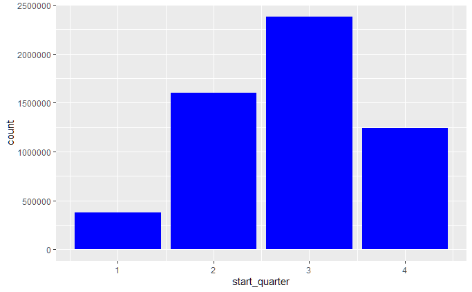

```r
bike_share %>%
  ggplot(mapping = aes(x = start_quarter)) +
  geom_bar(fill = "blue")
```

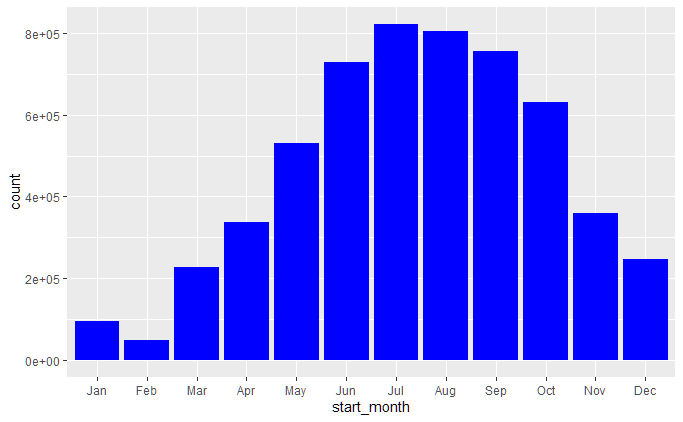

```r
bike_share %>%
  ggplot(mapping = aes(x = start_month)) +
  geom_bar(fill = "blue")
```

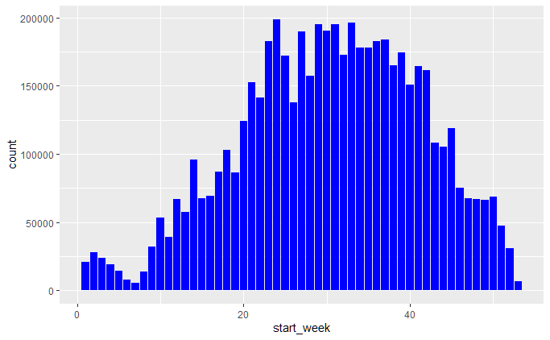

```r
bike_share %>%
  ggplot(mapping = aes(x = start_week)) +
  geom_bar(fill = "blue")
```

The ride counts appear to be appropriate given Chicago’s weather pattern. There are no obvious gaps in the data.

Let’s look at ride counts by day of the week.

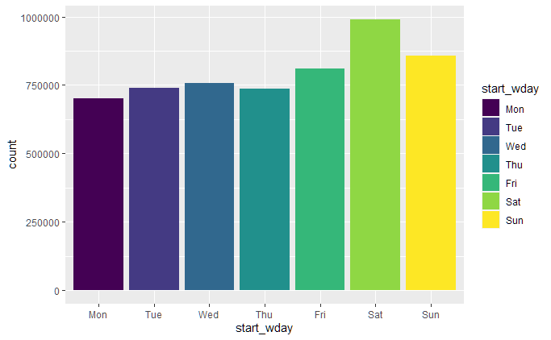

```r
bike_share %>%
  ggplot(mapping = aes(x = start_wday)) +
  geom_bar(mapping = aes(fill = start_wday))
```

Ride counts are higher on weekends. Let’s see if the pattern holds across quarters.

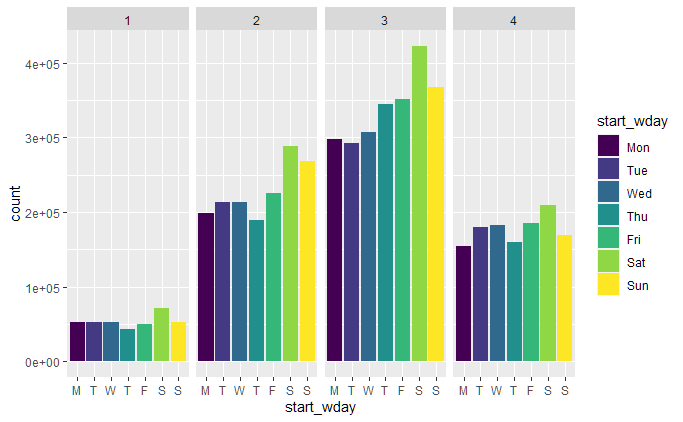

```r
bike_share %>%
  ggplot(mapping = aes(x = start_wday)) +
  geom_bar(mapping = aes(fill = start_wday)) +
  scale_x_discrete(labels = substr(levels(bike_share$start_wday), 1, 1)) +
  facet_wrap(~ start_quarter, nrow = 1)
```

Looks like the pattern holds. But it’s important to remember that this data is aggregated by quarter and by day of the week, and the days of the week are not equally distributed across quarters. At any rate, there’s no sign here of missing or unusual data.

Let’s see whether the pattern changes by type of bike.

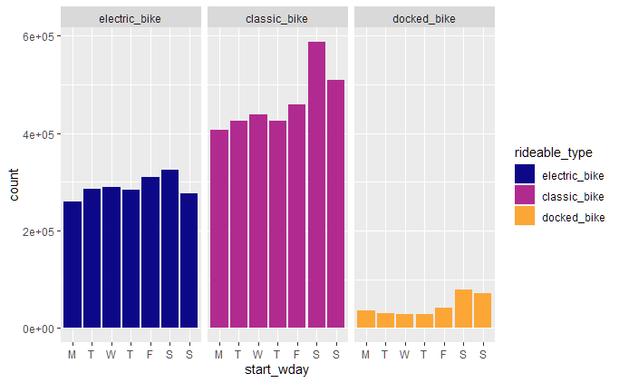

```r
bike_share %>%
  ggplot(mapping = aes(x = start_wday)) +
  geom_bar(mapping = aes(fill = rideable_type)) +
  scale_x_discrete(labels = substr(levels(bike_share$start_wday), 1, 1)) +
  scale_fill_viridis_d(option = "plasma", end = 0.8, drop = FALSE) +
  facet_wrap(~ rideable_type)
```

Interestingly, the counts of electric bikes rides don’t increase as much on weekends, and the Sunday rides with electric bikes have lower counts than most weekdays.

Let’s look at ride counts by day of the month.

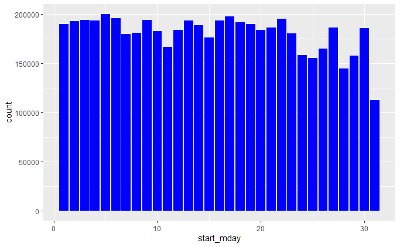

```r
bike_share %>%
  ggplot(mapping = aes(x = start_mday)) +
  geom_bar(fill = "blue")
```

The distribution by day of the month is roughly uniform as expected. But there’s a decrease in certain days toward the end of the month. Let’s look at it by month.

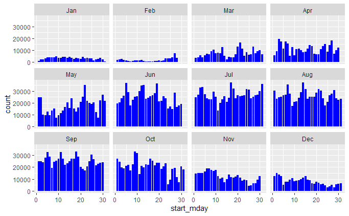

```r
bike_share %>%
  ggplot(mapping = aes(x = start_mday)) +
  geom_bar(fill = "blue") +
  facet_wrap(~ start_month, nrow = 3)
```

There are some days with sharp drops in ride counts in late May, October, and November. These could be due to factors like weather or holidays. But it’s also possible that there’s missing data for some days like May 28, July 11, and October 24, 25, 28, and 29. All of those days had slightly lower counts in the previous bar chart of counts by day of the month.

Let’s see whether the drops in counts are related to bike type. We’ll look at the proportions of rides for each day of the month.

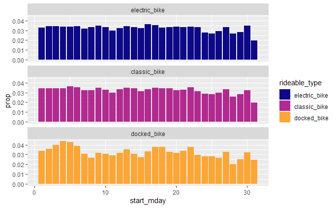

```r
bike_share %>%
  ggplot(mapping = aes(x = start_mday, y = ..prop..)) +
  geom_bar(mapping = aes(fill = rideable_type)) +
  scale_fill_viridis_d(option = "plasma", end = 0.8, drop = FALSE) +
  facet_wrap(~ rideable_type, nrow = 3)
```

The patterns for electric and classic bikes are very similar. There’s more variation in the pattern for the docked bikes. But we see certain days, like the 11th, 24th, 25th, 26th, 28th, and 29th have lower proportions of rides in each category.

This may be caused by missing data for some days, or there may be some other cause of the lowered ride counts on certain days. It could be that these days had worse weather than average in 2021. Without more information, it’s not possible to be sure the data is complete. However, while there may be missing data, the distributions aren’t so far from being uniform as to make us suspect that there’s a large volume of missing data. We’ll make a note of the days with lower ride counts in the data summary.

Let’s look at the distribution of rides by hour of the day.

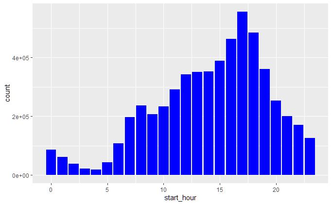

```r
bike_share %>%
  ggplot(mapping = aes(x = start_hour)) +
  geom_bar(fill = "blue")
```

The number of rides falls to its lowest level around 4 a.m., then rises to a peak around 8 a.m. Then there’s a slight dip, followed by a rise to a peak around 5 p.m. Let’s see if this pattern holds when we look at rides by quarter.

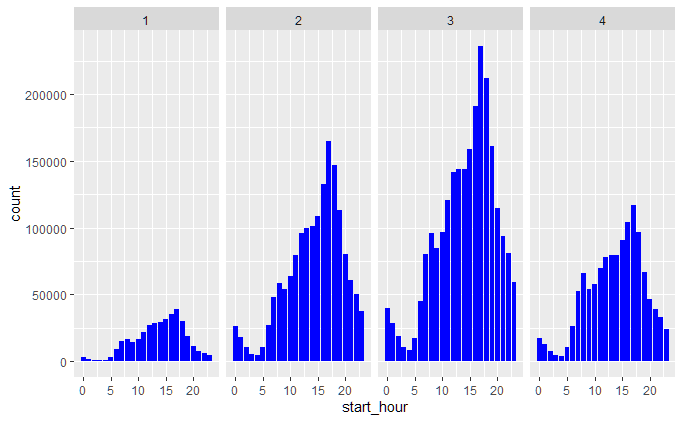

```r
bike_share %>%
  ggplot(mapping = aes(x = start_hour)) +
  geom_bar(fill = "blue") +
  facet_wrap(~ start_quarter, nrow = 1)
```

The general pattern appears to hold, with seasonal variation of volumes. We can check that by plotting proportions rather than absolute counts.

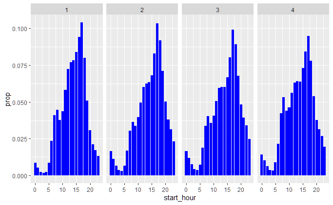

```r
bike_share %>%
  ggplot(mapping = aes(x = start_hour, y = ..prop..)) +
  geom_bar(fill = "blue") +
  facet_wrap(~ start_quarter, nrow = 1)
```

The plots for different quarters agree very well.

Let’s see whether the pattern changes by day of the week.

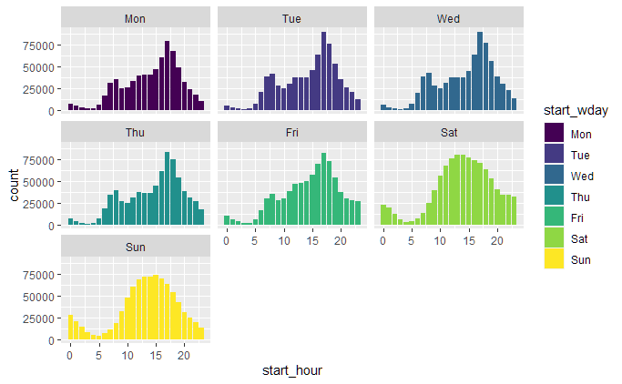

```r
bike_share %>%
  ggplot(mapping = aes(x = start_hour)) +
  geom_bar(mapping = aes(fill = start_wday)) +
  facet_wrap(~ start_wday)
```

The ride distributions by hour are very different depending on the day of the week. On weekdays, there are two peaks around 8 a.m. and 5 p.m. On weekends, there’s a single wider peak between 1 and 3 p.m, with fewer morning rides. There are also more late evening rides on Friday and Saturday.

Let’s see whether bike type influences these distributions. First we’ll look at the overall hourly distributions, using proportions rather than total counts.

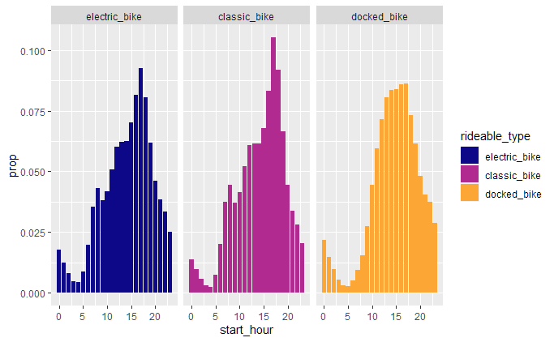

```r
bike_share %>%
  ggplot(mapping = aes(x = start_hour, y = ..prop..)) +
  geom_bar(mapping = aes(fill = rideable_type)) +
  scale_fill_viridis_d(option = "plasma", end = 0.8, drop = FALSE) +
  facet_wrap(~ rideable_type)
```

The hourly distribution of the docked bike rides is smoother and doesn’t show the sharp morning and evening peaks found in the distributions for electric and classic bikes.

Let’s break this down by day of the week.

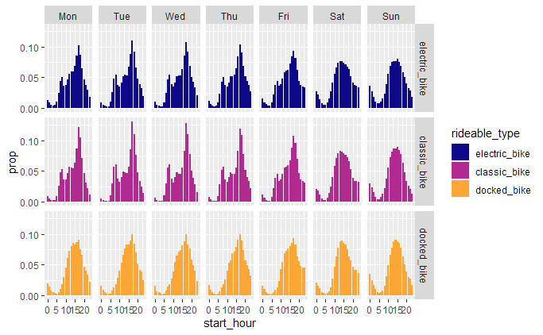

```r
bike_share %>%
  ggplot(mapping = aes(x = start_hour, y = ..prop..)) +
  geom_bar(mapping = aes(fill = rideable_type)) +
  scale_fill_viridis_d(option = "plasma", end = 0.8, drop = FALSE) +
  facet_grid(rideable_type ~ start_wday)
```

The hourly distributions for docked bikes don’t show a significant difference between weekdays and weekends. They tend to have the same type of distribution on all days of the week, and it roughly matches the distribution seen on weekends for electric and classic bikes.

Let’s check whether the relative counts of bike types change by day of the week.

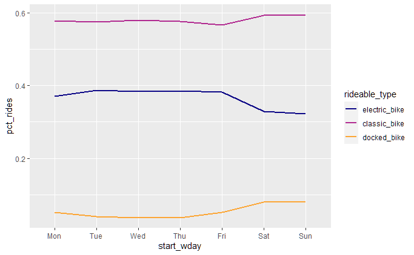

```r
bike_share %>%
  group_by(start_wday) %>%
  mutate(wday_ride_count = n(), .groups = "keep") %>%
  group_by(start_wday, rideable_type) %>%
  summarize(pct_rides = n() / wday_ride_count, .groups = "keep") %>%
  ggplot(mapping = aes(x = start_wday, y = pct_rides, group = rideable_type)) +
  geom_line(mapping = aes(color = rideable_type), size = 1) +
  scale_color_viridis_d(option = "plasma", end = 0.8, drop = FALSE)
```

The percentages of rides on classic and docked bikes rise on the weekends, but the percentage of rides on electric bikes falls on the weekends.

Let’s look at quarterly counts.

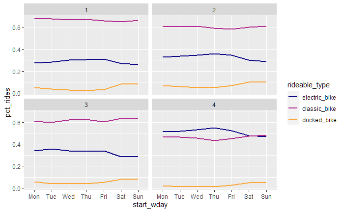

[figure not shown]

```r
bike_share %>%
  group_by(start_quarter, start_wday) %>%
  mutate(wday_ride_count = n(), .groups = "keep") %>%
  group_by(start_quarter, start_wday, rideable_type) %>%
  summarize(pct_rides = n() / wday_ride_count, .groups = "keep") %>%
  ggplot(mapping = aes(x = start_wday, y = pct_rides, group = rideable_type)) +
  geom_line(mapping = aes(color = rideable_type), size = 1) +
  scale_color_viridis_d(option = "plasma", end = 0.8, drop = FALSE) +
  facet_wrap(~ start_quarter)
```

The pattern holds in general, but in the fourth quarter the proportion of electric bikes increases and overtakes the proportion of classic bikes. This agrees with the earlier observation that the numbers of rides on electric bikes didn’t decrease in the last quarter as much as the numbers of rides on the other bike types.

Let’s see if the hour of the day affect the relative counts of bike types.

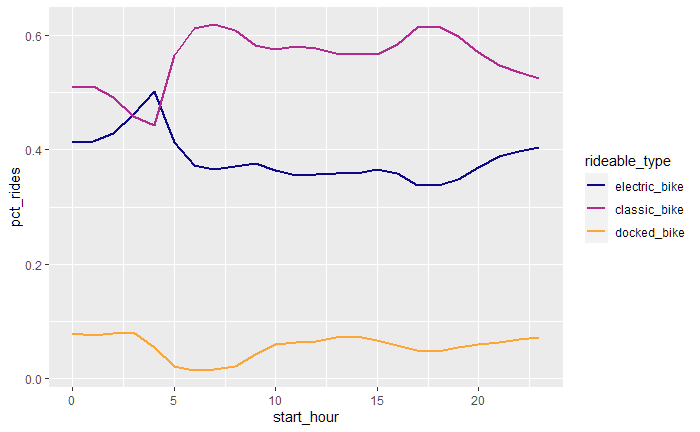

```r
bike_share %>%
  group_by(start_hour) %>%
  mutate(hour_ride_count = n(), .groups = "keep") %>%
  group_by(start_hour, rideable_type) %>%
  summarize(pct_rides = n() / hour_ride_count, .groups = "keep") %>%
  ggplot(mapping = aes(x = start_hour, y = pct_rides, group = rideable_type)) +
  geom_line(mapping = aes(color = rideable_type), size = 1) +
  scale_color_viridis_d(option = "plasma", end = 0.8, drop = FALSE)
```

There’s an increase in the percentage of electric bike rides in the evening and early morning hours. Let’s see whether this pattern holds across quarters.

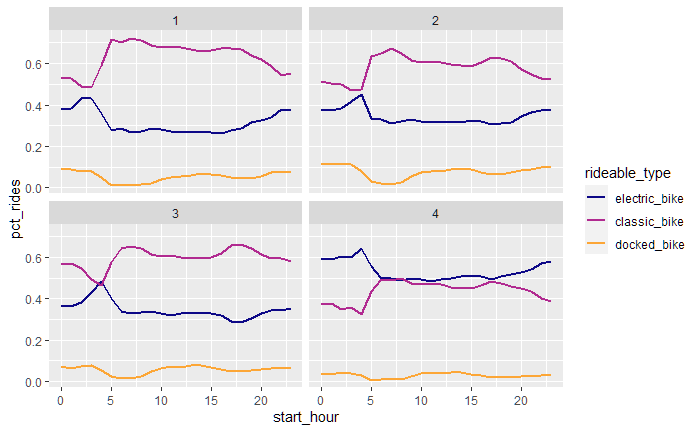

```r
bike_share %>%
  group_by(start_quarter, start_hour) %>%
  mutate(hour_ride_count = n(), .groups = "keep") %>%
  group_by(start_quarter, start_hour, rideable_type) %>%
  summarize(pct_rides = n() / hour_ride_count, .groups = "keep") %>%
  ggplot(mapping = aes(x = start_hour, y = pct_rides, group = rideable_type)) +
  geom_line(mapping = aes(color = rideable_type), size = 1) +
  scale_color_viridis_d(option = "plasma", end = 0.8, drop = FALSE) +
  facet_wrap(~ start_quarter)
```

The pattern holds in general.

In this extended look at the data for ride start time, there’s been nothing to indicate that there are significant data gaps. But there are indications that a small number of days may not have complete data.

### Exploring - ride_duration

Let’s take a look at the summary statistics for ride_duration.

```r
summary(bike_share$ride_duration)
```

```
                                Min.                              1st Qu.
          "-3482s (~-58.03 minutes)"               "405s (~6.75 minutes)"
                              Median                                 Mean
                "720s (~12 minutes)" "1316.12068961511s (~21.94 minutes)"
                             3rd Qu.                                 Max.
            "1307s (~21.78 minutes)"             "3356649s (~5.55 weeks)"
```

There are some rides with negative duration. Also, the median duration is 12 minutes, but the mean duration is 22 minutes, which suggests a skewed distribution. The maximum ride is over 5 weeks, which is interesting.

Let’s look at a histogram of ride durations. Since the ride_duration column is in seconds, we’ll divide the duration by 3600 so the x-axis is in hours. We’ll use a bin width of one hour.

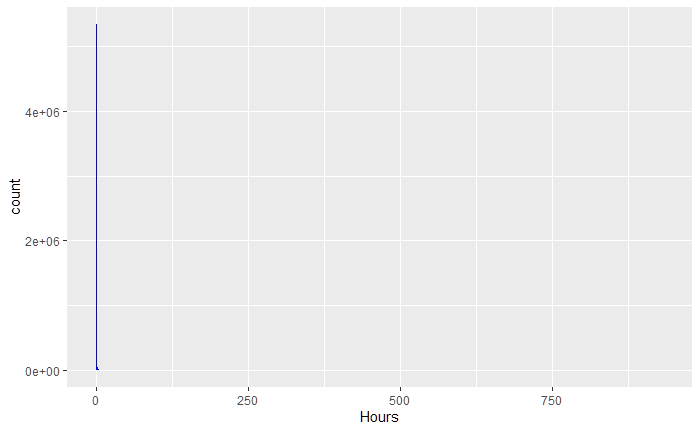

```r
bike_share %>%
  ggplot(mapping = aes(x = ride_duration / 3600)) +
  geom_histogram(binwidth = 1, boundary = 0, fill = "blue", closed = "left") +
  xlab("Hours")
```

We need to limit the scope of the y-axis to get a better view of the low numbers of long-duration rides. We’ll use a bin width of one day.

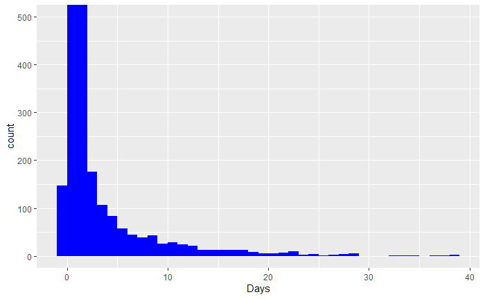

```r
bike_share %>%
  ggplot(mapping = aes(x = ride_duration / 3600 / 24)) +
  geom_histogram(binwidth = 1, boundary = 0, fill = "blue", closed = "left") +
  xlab("Days") +
  coord_cartesian(ylim = c(0, 500))
```

We see that there are about 150 rides with negative duration, and the rides of long duration fall off sharply after two days. The distribution looks like it may be exponential. Let’s look at a histogram of the log of the duration. We’ll need to exclude rides with non-positive duration. We’ll divide the duration by 60, so that the x-axis will represent the log of minutes. But we’ll label the x-axis with minutes rather than the log of minutes.

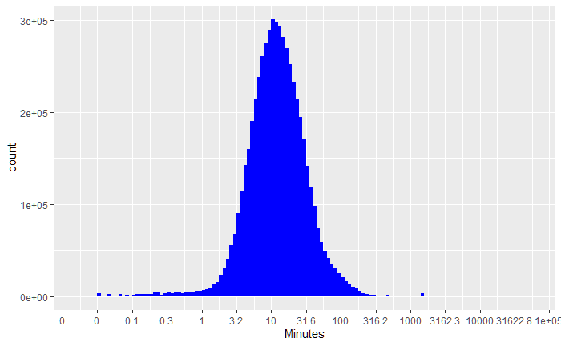

```r
bike_share %>%
  filter(ride_duration > 0) %>%
  ggplot(mapping = aes(x = ride_duration / 60)) +
  geom_histogram(
    binwidth = 0.05,
    boundary = 0,
    closed = "left",
    fill = "blue"
  ) +
  scale_x_log10(
    breaks = 10 ^ seq(-5,5, by = 0.5),
    labels = round(10 ^ seq(-5,5, by = 0.5), 1)
  ) +
  xlab("Minutes")
```

We see that the distribution of the log of duration is symmetrical. Most rides last between 1 and 100 minutes, with the most common ride length slightly more than ten minutes. This agrees with the median of 12 minutes noted above.

Let’s take a look at the rides with a negative duration. We already know the minimum ride duration is about -58 minutes. Well convert to minutes, and use a bin width of 5 minutes.

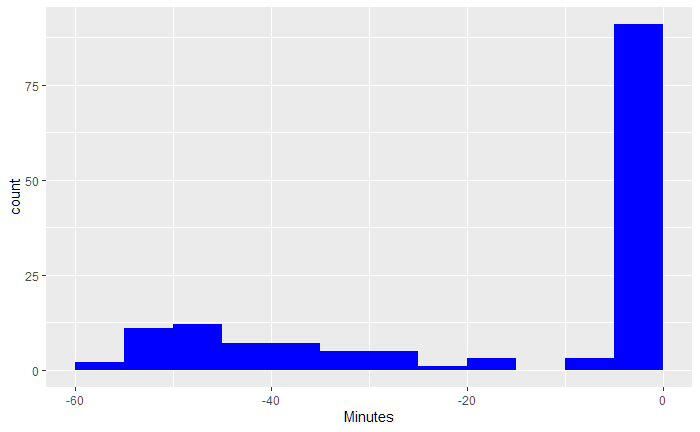

```r
bike_share %>%
  filter(ride_duration < 0) %>%
  ggplot(mapping = aes(x = ride_duration / 60)) +
  geom_histogram(binwidth = 5, boundary = 0, fill = "blue", closed = "left") +
  xlab(label = "Minutes")
```

Let’s break them out by month and date to see whether there’s any pattern to their occurrence.

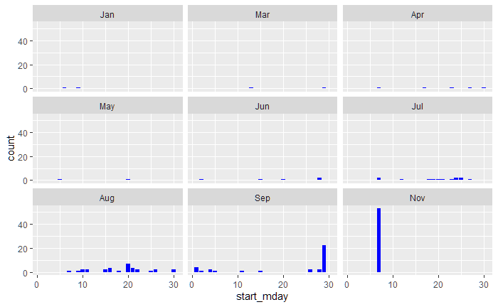

```r
bike_share %>%
  filter(ride_duration < 0) %>%
  ggplot(mapping = aes(x = start_mday)) +
  geom_bar(fill = "blue") +
  facet_wrap(~ start_month)
```

November 7 has the largest number of rides with negative duration, which are likely due to the change from Daylight Saving Time to standard time. Let’s look at the start and end times of those rides.

```r
bike_share %>%
  filter(ride_duration < 0 & start_month == "Nov") %>%
  select(started_at, ended_at) %>%
  summary()
```

```
   started_at                     ended_at
 Min.   :2021-11-07 01:19:04   Min.   :2021-11-07 01:00:06
 1st Qu.:2021-11-07 01:45:48   1st Qu.:2021-11-07 01:02:26
 Median :2021-11-07 01:52:53   Median :2021-11-07 01:05:09
 Mean   :2021-11-07 01:49:15   Mean   :2021-11-07 01:07:50
 3rd Qu.:2021-11-07 01:54:37   3rd Qu.:2021-11-07 01:09:02
 Max.   :2021-11-07 01:59:53   Max.   :2021-11-07 01:27:02
```

All of these rides began and ended in the 1 a.m. hour. Since the 1 a.m. hour occurred twice, these rides very likely took an hour more than the time that was recorded. We can confidently add an hour to these rides. We’ll get a count of them before changing them.

```r
bike_share %>%
  filter(ride_duration < 0 & start_month == "Nov") %>%
  nrow()
```

```
[1] 53
```

53 rows will be updated.

```r
bike_share <- bike_share %>%
  mutate(ride_duration = ifelse(
                           ride_duration < 0 & start_month == "Nov",
                           ride_duration + 3600,
                           ride_duration
                         )
  )
```

Let’s look at the remaining rides with negative duration again.

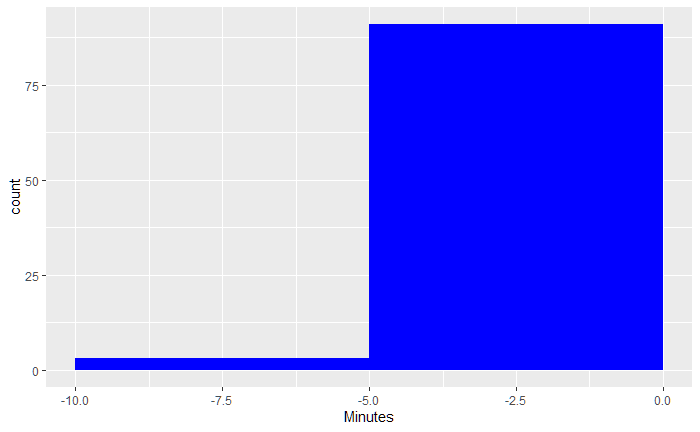

```r
bike_share %>%
  filter(ride_duration < 0) %>%
  ggplot(mapping = aes(x = ride_duration / 60)) +
  geom_histogram(binwidth = 5, boundary = 0, fill = "blue", closed = "left") +
  xlab(label = "Minutes")
```

We’re left with less than a hundred rides with durations no lower than -10 minutes. Without more information on the cause of the incorrect times, it’s best to remove these rides from the data set.